# Concrete Strength Prediction

### Problem Statement

To predict the concrete strength using the data available in file "concrete.csv". Apply feature engineering and model tuning to obtain a score above 85%.

### Data

The data for this project is available in file https://archive.ics.uci.edu/ml/machine-learning-databases/concrete/compressive/

Given are the variable name, variable type, the measurement unit, and a brief description. The concrete compressive strength is the regression problem. The order of this listing corresponds to the order of numerals along the rows of the database.

- Cement (cement) -- quantitative -- kg in a m3 mixture -- Input Variable
- Blast Furnace Slag (slag) -- quantitative -- kg in a m3 mixture -- Input Variable
- Fly Ash (ash) -- quantitative -- kg in a m3 mixture -- Input Variable
- Water (water) -- quantitative -- kg in a m3 mixture -- Input Variable
- Superplasticizer (superplastic) -- quantitative -- kg in a m3 mixture -- Input Variable
- Coarse Aggregate (coarseagg) -- quantitative -- kg in a m3 mixture -- Input Variable
- Fine Aggregate (fineagg) -- quantitative -- kg in a m3 mixture -- Input Variable
- Age(age) -- quantitative -- Day (1~365) -- Input Variable
- Concrete compressive strength(strength) -- quantitative -- MPa -- Output Variable

Github Link: https://github.com/deepak-padmanabhan/PGP-AIML

```python
import warnings
warnings.filterwarnings('ignore')
```

```python
import pandas as pd
import numpy as np
import matplotlib.pyplot as plt
%matplotlib inline
# To enable plotting graphs in Jupyter notebook
import seaborn as sns
import itertools

# Remove scientific notations and display numbers with 2 decimal points instead
pd.options.display.float_format = '{:,.2f}'.format

#Sklearn package's data splitting function which is based on random function
from sklearn.model_selection import train_test_split
from sklearn import metrics
from sklearn import preprocessing
from sklearn.preprocessing import StandardScaler
from sklearn.model_selection import KFold
from sklearn.model_selection import cross_val_score
from sklearn.preprocessing import PolynomialFeatures
from sklearn.ensemble import RandomForestRegressor
from sklearn.tree import DecisionTreeRegressor
from sklearn.ensemble import BaggingRegressor
from sklearn.ensemble import AdaBoostRegressor
from sklearn.ensemble import RandomForestRegressor
from sklearn.ensemble import GradientBoostingRegressor
from sklearn.model_selection import GridSearchCV, RandomizedSearchCV
```

```python
data = []
data = pd.read_csv('concrete.csv')
data.head()
```

|  | cement | slag | ash | water | superplastic | coarseagg | fineagg | age | strength |
| --- | --- | --- | --- | --- | --- | --- | --- | --- | --- |
| 0 | 141.30 | 212.00 | 0.00 | 203.50 | 0.00 | 971.80 | 748.50 | 28 | 29.89 |
| 1 | 168.90 | 42.20 | 124.30 | 158.30 | 10.80 | 1,080.80 | 796.20 | 14 | 23.51 |
| 2 | 250.00 | 0.00 | 95.70 | 187.40 | 5.50 | 956.90 | 861.20 | 28 | 29.22 |
| 3 | 266.00 | 114.00 | 0.00 | 228.00 | 0.00 | 932.00 | 670.00 | 28 | 45.85 |
| 4 | 154.80 | 183.40 | 0.00 | 193.30 | 9.10 | 1,047.40 | 696.70 | 28 | 18.29 |

### Univariate Analysis

```python
data.shape
```

```
(1030, 9)
```

The dataset contains 1030 rows and 9 columns

```python
data.info()
```

```
<class 'pandas.core.frame.DataFrame'>
RangeIndex: 1030 entries, 0 to 1029
Data columns (total 9 columns):
 #   Column        Non-Null Count  Dtype
---  ------        --------------  -----
 0   cement        1030 non-null   float64
 1   slag          1030 non-null   float64
 2   ash           1030 non-null   float64
 3   water         1030 non-null   float64
 4   superplastic  1030 non-null   float64
 5   coarseagg     1030 non-null   float64
 6   fineagg       1030 non-null   float64
 7   age           1030 non-null   int64
 8   strength      1030 non-null   float64
dtypes: float64(8), int64(1)
memory usage: 72.5 KB
```

```python
data.describe().transpose()
```

|  | count | mean | std | min | 25% | 50% | 75% | max |
| --- | --- | --- | --- | --- | --- | --- | --- | --- |
| cement | 1,030.00 | 281.17 | 104.51 | 102.00 | 192.38 | 272.90 | 350.00 | 540.00 |
| slag | 1,030.00 | 73.90 | 86.28 | 0.00 | 0.00 | 22.00 | 142.95 | 359.40 |
| ash | 1,030.00 | 54.19 | 64.00 | 0.00 | 0.00 | 0.00 | 118.30 | 200.10 |
| water | 1,030.00 | 181.57 | 21.35 | 121.80 | 164.90 | 185.00 | 192.00 | 247.00 |
| superplastic | 1,030.00 | 6.20 | 5.97 | 0.00 | 0.00 | 6.40 | 10.20 | 32.20 |
| coarseagg | 1,030.00 | 972.92 | 77.75 | 801.00 | 932.00 | 968.00 | 1,029.40 | 1,145.00 |
| fineagg | 1,030.00 | 773.58 | 80.18 | 594.00 | 730.95 | 779.50 | 824.00 | 992.60 |
| age | 1,030.00 | 45.66 | 63.17 | 1.00 | 7.00 | 28.00 | 56.00 | 365.00 |
| strength | 1,030.00 | 35.82 | 16.71 | 2.33 | 23.71 | 34.45 | 46.14 | 82.60 |

```python
data.isnull().sum()
```

```
cement          0
slag            0
ash             0
water           0
superplastic    0
coarseagg       0
fineagg         0
age             0
strength        0
dtype: int64
```

```python
data.isna().sum()
```

```
cement          0
slag            0
ash             0
water           0
superplastic    0
coarseagg       0
fineagg         0
age             0
strength        0
dtype: int64
```

- Dataset contains numerical values
- There are no null values across all columns
- Age appears to have higher values outside of the 75% quantile. Will impute outliers before building the model
- Columns, except for Age and Strength, have the same "kg in a m3 mixture" unit. Will use standard scaler before building the model

```python
# Checking for duplicates
data[data.duplicated()]
```

|  | cement | slag | ash | water | superplastic | coarseagg | fineagg | age | strength |
| --- | --- | --- | --- | --- | --- | --- | --- | --- | --- |
| 278 | 425.00 | 106.30 | 0.00 | 153.50 | 16.50 | 852.10 | 887.10 | 3 | 33.40 |
| 298 | 425.00 | 106.30 | 0.00 | 153.50 | 16.50 | 852.10 | 887.10 | 3 | 33.40 |
| 400 | 362.60 | 189.00 | 0.00 | 164.90 | 11.60 | 944.70 | 755.80 | 3 | 35.30 |
| 420 | 362.60 | 189.00 | 0.00 | 164.90 | 11.60 | 944.70 | 755.80 | 3 | 35.30 |
| 463 | 362.60 | 189.00 | 0.00 | 164.90 | 11.60 | 944.70 | 755.80 | 56 | 77.30 |
| 468 | 252.00 | 0.00 | 0.00 | 185.00 | 0.00 | 1,111.00 | 784.00 | 28 | 19.69 |
| 482 | 425.00 | 106.30 | 0.00 | 153.50 | 16.50 | 852.10 | 887.10 | 91 | 65.20 |
| 493 | 362.60 | 189.00 | 0.00 | 164.90 | 11.60 | 944.70 | 755.80 | 91 | 79.30 |
| 517 | 425.00 | 106.30 | 0.00 | 153.50 | 16.50 | 852.10 | 887.10 | 56 | 64.30 |
| 525 | 362.60 | 189.00 | 0.00 | 164.90 | 11.60 | 944.70 | 755.80 | 28 | 71.30 |
| 527 | 425.00 | 106.30 | 0.00 | 153.50 | 16.50 | 852.10 | 887.10 | 91 | 65.20 |
| 576 | 362.60 | 189.00 | 0.00 | 164.90 | 11.60 | 944.70 | 755.80 | 7 | 55.90 |
| 577 | 425.00 | 106.30 | 0.00 | 153.50 | 16.50 | 852.10 | 887.10 | 28 | 60.29 |
| 604 | 362.60 | 189.00 | 0.00 | 164.90 | 11.60 | 944.70 | 755.80 | 56 | 77.30 |
| 733 | 362.60 | 189.00 | 0.00 | 164.90 | 11.60 | 944.70 | 755.80 | 91 | 79.30 |
| 738 | 362.60 | 189.00 | 0.00 | 164.90 | 11.60 | 944.70 | 755.80 | 28 | 71.30 |
| 766 | 362.60 | 189.00 | 0.00 | 164.90 | 11.60 | 944.70 | 755.80 | 91 | 79.30 |
| 830 | 425.00 | 106.30 | 0.00 | 153.50 | 16.50 | 852.10 | 887.10 | 7 | 49.20 |
| 880 | 425.00 | 106.30 | 0.00 | 153.50 | 16.50 | 852.10 | 887.10 | 56 | 64.30 |
| 884 | 425.00 | 106.30 | 0.00 | 153.50 | 16.50 | 852.10 | 887.10 | 7 | 49.20 |
| 892 | 362.60 | 189.00 | 0.00 | 164.90 | 11.60 | 944.70 | 755.80 | 56 | 77.30 |
| 933 | 362.60 | 189.00 | 0.00 | 164.90 | 11.60 | 944.70 | 755.80 | 7 | 55.90 |
| 943 | 362.60 | 189.00 | 0.00 | 164.90 | 11.60 | 944.70 | 755.80 | 3 | 35.30 |
| 967 | 362.60 | 189.00 | 0.00 | 164.90 | 11.60 | 944.70 | 755.80 | 28 | 71.30 |
| 992 | 425.00 | 106.30 | 0.00 | 153.50 | 16.50 | 852.10 | 887.10 | 28 | 60.29 |

```python
data[data.duplicated()].count()
```

```
cement          25
slag            25
ash             25
water           25
superplastic    25
coarseagg       25
fineagg         25
age             25
strength        25
dtype: int64
```

```python
# Removing Duplicate Rows
data = data.drop_duplicates()
```

```python
# Checking if duplicates got removed
data[data.duplicated()]
```

|  | cement | slag | ash | water | superplastic | coarseagg | fineagg | age | strength |
| --- | --- | --- | --- | --- | --- | --- | --- | --- | --- |

- 25 duplicate rows found in the dataset which got dropped

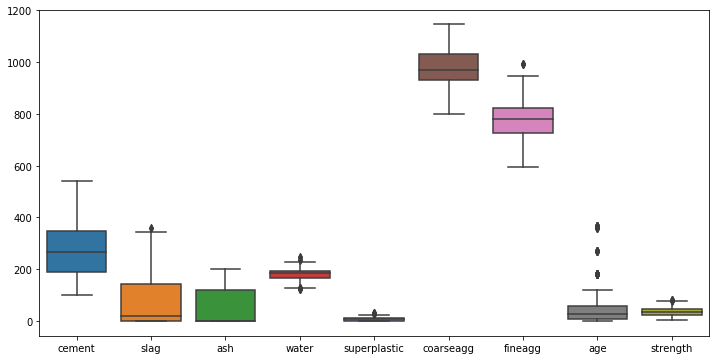

```python
plt.subplots(figsize=(12, 6))
ax = sns.boxplot(data=data)
```

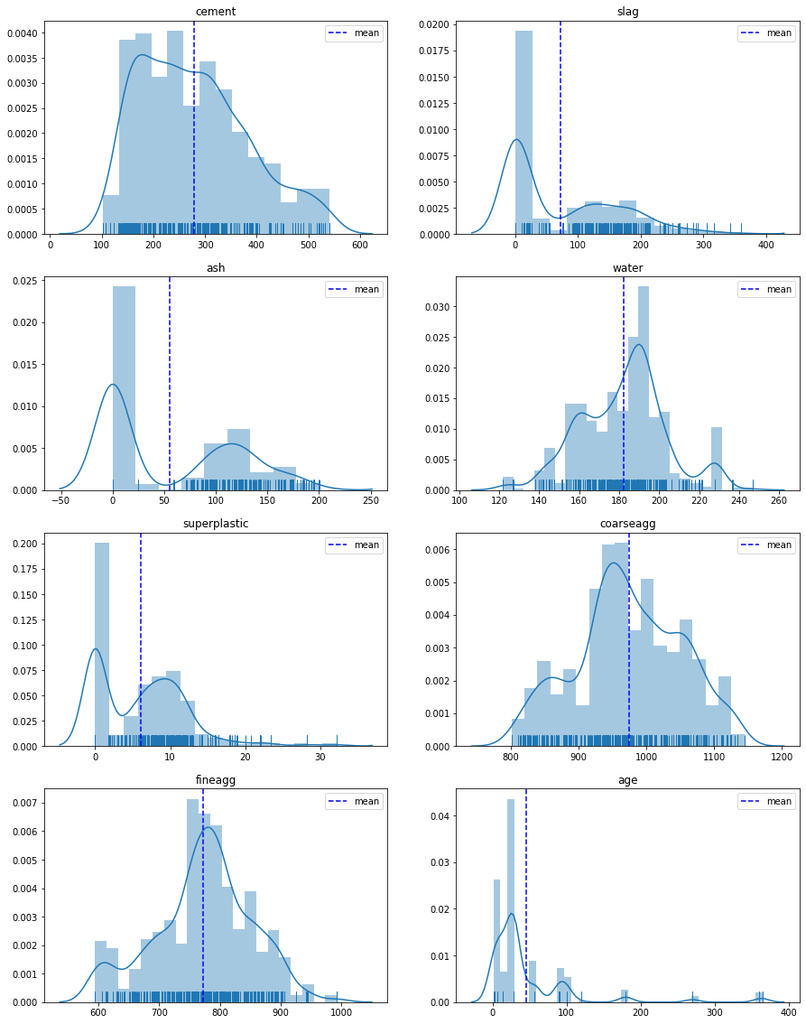

```python
cols = [i for i in data.columns if i != 'strength']

plt.figure(figsize=(15, 20))

for i,j in itertools.zip_longest(cols, range(len(cols))):
    plt.subplot(4,2,j+1)
    ax = sns.distplot(data[i],rug=True)
    plt.axvline(data[i].mean(),linestyle="dashed",label="mean", color='blue')
    plt.legend()
    plt.title(i)
    plt.xlabel("")
```

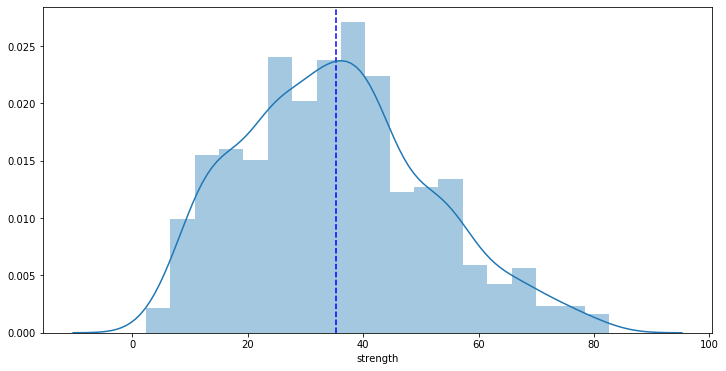

```python
plt.figure(figsize=(12, 6))
plt.axvline(data['strength'].mean(),linestyle="dashed",label="mean", color='blue')
sns.distplot(data['strength'])
```

```python
data.skew()
```

```
cement          0.56
slag            0.86
ash             0.50
water           0.03
superplastic    0.98
coarseagg      -0.07
fineagg        -0.25
age             3.25
strength        0.40
dtype: float64
```

- Slag, Water, Superplastic, Fineagg, Age, Strength appears to have outliers
- Cement and Strength seems to have a normal distribution
- Slag, Ash, Superplastic appears to have multiple gaussians

### Bivariate Analysis

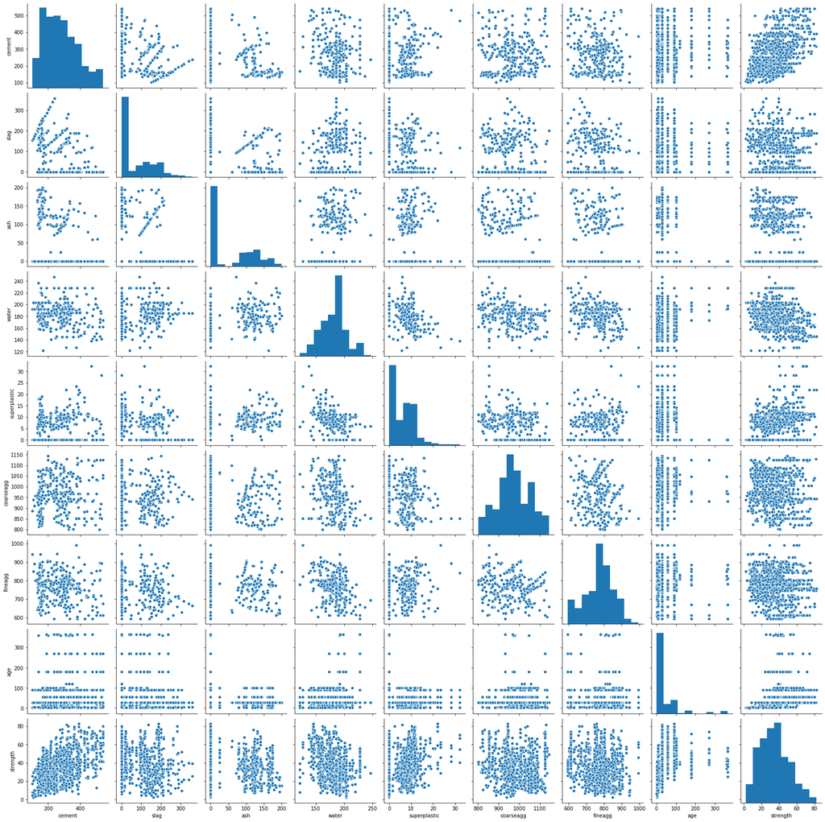

```python
sns.pairplot(data)
plt.show()
```

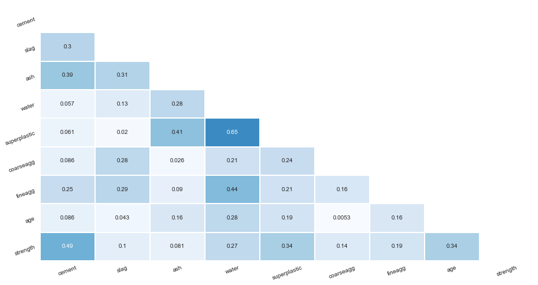

```python
corr = abs(data.corr()) # correlation matrix
lower_triangle = np.tril(corr, k = -1)  # select only the lower triangle of the correlation matrix
mask = lower_triangle == 0  # to mask the upper triangle in the following heatmap

plt.figure(figsize = (15,8))  # setting the figure size
sns.set_style(style = 'white')  # Setting it to white so that we do not see the grid lines
sns.heatmap(lower_triangle, center=0.5, cmap= 'Blues', annot= True, xticklabels = corr.index, yticklabels = corr.columns,
            cbar= False, linewidths= 1, mask = mask)
plt.xticks(rotation = 20)   # Aesthetic purposes
plt.yticks(rotation = 20)   # Aesthetic purposes
plt.show()
```

### Feature Engineering / Data Preparation

```python
# Checking for outliers using IQR
df = data.copy()
Q1 = df.quantile(0.25)
Q3 = df.quantile(0.75)
IQR = Q3 - Q1
print("Number of outliers above Q3 + 1.5*IQR ")
df[df>(Q3+1.5*IQR)].count()
```

```
Number of outliers above Q3 + 1.5*IQR
```

```
cement           0
slag             2
ash              0
water            4
superplastic    10
coarseagg        0
fineagg          5
age             59
strength         8
dtype: int64
```

```python
print("Number of outliers below Q1 - 1.5*IQR ")
df[df<(Q1-1.5*IQR)].count()
```

```
Number of outliers below Q1 - 1.5*IQR
```

```
cement           0
slag             0
ash              0
water           11
superplastic     0
coarseagg        0
fineagg          0
age              0
strength         0
dtype: int64
```

```python
# Treating outliers by replacing lower side with lower whisker and upper side with upper whisker

for i,j in zip(np.where(df < Q1 - 1.5 * IQR)[0],np.where(df < Q1 - 1.5 * IQR)[1]):
    whisker = Q1 - 1.5 * IQR
    df.iloc[i,j] = whisker[j]

for i,j in zip(np.where(df > Q3 + 1.5 * IQR)[0],np.where(df > Q3 + 1.5 * IQR)[1]):
    whisker = Q3 + 1.5 * IQR
    df.iloc[i,j] = whisker[j]
```

```python
print("Number of outliers above Q3 + 1.5*IQR ")
df[df>(Q3+1.5*IQR)].count()
```

```
Number of outliers above Q3 + 1.5*IQR
```

```
cement          0
slag            0
ash             0
water           0
superplastic    0
coarseagg       0
fineagg         0
age             0
strength        0
dtype: int64
```

```python
print("Number of outliers below Q1 - 1.5*IQR ")
df[df<(Q1-1.5*IQR)].count()
```

```
Number of outliers below Q1 - 1.5*IQR
```

```
cement          0
slag            0
ash             0
water           0
superplastic    0
coarseagg       0
fineagg         0
age             0
strength        0
dtype: int64
```

```python
#Scaling the dataset using Standard Scaler
cols_to_scale=df.columns
from sklearn.preprocessing import StandardScaler
scaler=StandardScaler()
df[cols_to_scale]=scaler.fit_transform(df[cols_to_scale])
df.head()
```

|  | cement | slag | ash | water | superplastic | coarseagg | fineagg | age | strength |
| --- | --- | --- | --- | --- | --- | --- | --- | --- | --- |
| 0 | -1.32 | 1.63 | -0.87 | 1.01 | -1.05 | -0.03 | -0.30 | -0.28 | -0.33 |
| 1 | -1.05 | -0.35 | 1.07 | -1.12 | 0.84 | 1.37 | 0.30 | -0.67 | -0.72 |
| 2 | -0.27 | -0.84 | 0.63 | 0.25 | -0.08 | -0.23 | 1.11 | -0.28 | -0.37 |
| 3 | -0.12 | 0.49 | -0.87 | 2.17 | -1.05 | -0.55 | -1.28 | -0.28 | 0.66 |
| 4 | -1.19 | 1.29 | -0.87 | 0.53 | 0.55 | 0.94 | -0.95 | -0.28 | -1.04 |

```python
#Separating independent and dependent variables
X = df.drop("strength" , axis=1)
y = df["strength"]
```

```python
# Splitting the data into train and test

from sklearn.model_selection import train_test_split

X_train, X_test, y_train, y_test = train_test_split( X, y, test_size = 0.3, random_state = 1)
```

```python
# Defining the kFold function for the cross validation
from sklearn.model_selection import KFold
from sklearn.model_selection import cross_val_score

num_folds = 10
seed = 7

kfold = KFold(n_splits=num_folds, shuffle=True, random_state=seed)
```

```python
# Initializing for model comparison dataframe
linear_model = []
linear_model_training_score = []
linear_model_test_score = []
linear_model_kfoldmean = []
linear_model_kfold_rmse = []
```

### Creating Models

#### Linear Regression

```python
from sklearn.linear_model import LinearRegression
regression_model = LinearRegression()
regression_model.fit(X_train, y_train)
linear_model.append('Linear Regression')

lr_training_score = regression_model.score(X_train, y_train)
linear_model_training_score.append(lr_training_score)
print("Linear Regression Model Training Score:",lr_training_score)

lr_test_score = regression_model.score(X_test, y_test)
linear_model_test_score.append(lr_test_score)
print("Linear Regression Model Test Score:",lr_test_score)

lr_kfoldmean = cross_val_score(regression_model, X, y, cv=kfold).mean()
print("Linear Regression Model KFold Mean :", lr_kfoldmean)
linear_model_kfoldmean.append(lr_kfoldmean)

lr_kfold_rmse = np.sqrt((-1) * cross_val_score(regression_model, X, y, cv=kfold,scoring='neg_mean_squared_error').mean())
print("Linear Regression Model KFold RMSE :", lr_kfold_rmse)
linear_model_kfold_rmse.append(lr_kfold_rmse)
```

```
Linear Regression Model Training Score: 0.7351817182772616
Linear Regression Model Test Score: 0.6773099541878453
Linear Regression Model KFold Mean : 0.7141297621562461
Linear Regression Model KFold RMSE : 0.5331962751394943
```

#### Polynomial Regression - 2nd Degree

```python
from sklearn.preprocessing import PolynomialFeatures
poly_2D = PolynomialFeatures(degree=2, interaction_only=True)
X_poly_2D = poly_2D.fit_transform(X)
X_poly_2D_train, X_poly_2D_test, y_train, y_test = train_test_split(X_poly_2D, y, test_size = 0.3, random_state = 1)
X_poly_2D.shape
```

```
(1005, 37)
```

```python
linear_model.append('Polynomial Regression - 2D')
```

```python
poly2D = LinearRegression()
poly2D.fit(X_poly_2D_train, y_train)

poly_2D_training_score = poly2D.score(X_poly_2D_train, y_train)
print("2D Polynomial Model Training Score:",poly_2D_training_score)
linear_model_training_score.append(poly_2D_training_score)

poly_2D_test_score = poly2D.score(X_poly_2D_test, y_test)
print("2D Polynomial Model Test Score:",poly_2D_test_score)
linear_model_test_score.append(poly_2D_test_score)

poly_2D_kfoldmean = cross_val_score(poly2D, X_poly_2D, y, cv=kfold).mean()
print("2D Polynomial Model KFold Mean :", poly_2D_kfoldmean)
linear_model_kfoldmean.append(poly_2D_kfoldmean)

lr_kfold_rmse = np.sqrt((-1) * cross_val_score(poly2D, X_poly_2D, y, cv=kfold,scoring='neg_mean_squared_error').mean())
print("2D Polynomian Model KFold RMSE :", lr_kfold_rmse)
linear_model_kfold_rmse.append(lr_kfold_rmse)
```

```
2D Polynomial Model Training Score: 0.8039424683283436
2D Polynomial Model Test Score: 0.7382759056961676
2D Polynomial Model KFold Mean : 0.768079187736581
2D Polynomian Model KFold RMSE : 0.4803648985522539
```

#### Polynomial Regression - 3rd Degree

```python
from sklearn.preprocessing import PolynomialFeatures
poly_3D = PolynomialFeatures(degree=3, interaction_only=True)
X_poly_3D = poly_3D.fit_transform(X)
X_poly_3D_train, X_poly_3D_test, y_train, y_test = train_test_split(X_poly_3D, y, test_size = 0.3, random_state = 1)
X_poly_3D.shape
```

```
(1005, 93)
```

```python
linear_model.append('Polynomial Regression - 3D')
```

```python
poly3D = LinearRegression()
poly3D.fit(X_poly_3D_train, y_train)

poly_3D_training_score = poly3D.score(X_poly_3D_train, y_train)
print("3D Polynomial Model Training Score:",poly_3D_training_score)
linear_model_training_score.append(poly_3D_training_score)

poly_3D_test_score = poly3D.score(X_poly_3D_test, y_test)
print("3D Polynomial Model Test Score:",poly_3D_test_score)
linear_model_test_score.append(poly_3D_test_score)

poly_3D_kfoldmean = cross_val_score(poly3D, X_poly_3D, y, cv=kfold).mean()
print("3D Polynomial Model KFold Mean :", poly_3D_kfoldmean)
linear_model_kfoldmean.append(poly_3D_kfoldmean)

lr_kfold_rmse = np.sqrt((-1) * cross_val_score(poly3D, X_poly_3D, y, cv=kfold,scoring='neg_mean_squared_error').mean())
print("3D Polynomial Model KFold RMSE :", lr_kfold_rmse)
linear_model_kfold_rmse.append(lr_kfold_rmse)
```

```
3D Polynomial Model Training Score: 0.8464258262640845
3D Polynomial Model Test Score: 0.7368692246968656
3D Polynomial Model KFold Mean : 0.7765807655976248
3D Polynomial Model KFold RMSE : 0.4714997525588776
```

#### Random Forest Regressor

```python
linear_model.append('Random Forest Regressor')
rf = RandomForestRegressor(n_estimators=100)
rf.fit(X_train, y_train)
rf_training_score = rf.score(X_train, y_train)
print("Random Forest Model Training Score:",rf_training_score)
linear_model_training_score.append(rf_training_score)

rf_test_score = rf.score(X_test, y_test)
print("Random Forest Regressor Model Testing Set Score:", rf_test_score)
linear_model_test_score.append(rf_test_score)

rf_kfoldmean = cross_val_score(rf, X, y, cv=kfold).mean()
print("Random Forest Regressor Model KFold Mean :", rf_kfoldmean)
linear_model_kfoldmean.append(rf_kfoldmean)

lr_kfold_rmse = np.sqrt((-1) * cross_val_score(rf, X, y, cv=kfold,scoring='neg_mean_squared_error').mean())
print("Random Forest Model KFold RMSE :", lr_kfold_rmse)
linear_model_kfold_rmse.append(lr_kfold_rmse)
```

```
Random Forest Model Training Score: 0.983874579689282
Random Forest Regressor Model Testing Set Score: 0.8968938428549088
Random Forest Regressor Model KFold Mean : 0.9135912261654479
Random Forest Model KFold RMSE : 0.2966381321646026
```

#### Bagging

```python
linear_model.append('Bagging Regressor')
bg = BaggingRegressor(n_estimators=100)
bg.fit(X_train, y_train)
bg_training_score = bg.score(X_train, y_train)
print("Bagging Model Training Score:",bg_training_score)
linear_model_training_score.append(bg_training_score)

bg_test_score = bg.score(X_test, y_test)
print("Bagging Model Testing Set Score:", bg_test_score)
linear_model_test_score.append(bg_test_score)

bg_kfoldmean = cross_val_score(bg, X, y, cv=kfold).mean()
print("Bagging Model KFold Mean :", bg_kfoldmean)
linear_model_kfoldmean.append(bg_kfoldmean)

bg_kfold_rmse = np.sqrt((-1) * cross_val_score(bg, X, y, cv=kfold,scoring='neg_mean_squared_error').mean())
print("Bagging Model KFold RMSE :", bg_kfold_rmse)
linear_model_kfold_rmse.append(bg_kfold_rmse)
```

```
Bagging Model Training Score: 0.983487687419371
Bagging Model Testing Set Score: 0.8947853926377779
Bagging Model KFold Mean : 0.9118581799228636
Bagging Model KFold RMSE : 0.2967201678605777
```

#### Gradient Boosting

```python
linear_model.append('Gradient Boosting Regressor')
gb = GradientBoostingRegressor(n_estimators=100)
gb.fit(X_train, y_train)
gb_training_score = gb.score(X_train, y_train)
print("Gradient Boosting Model Training Score:",gb_training_score)
linear_model_training_score.append(gb_training_score)

gb_test_score = gb.score(X_test, y_test)
print("Gradient Boosting Regressor Model Testing Set Score:", gb_test_score)
linear_model_test_score.append(gb_test_score)

gb_kfoldmean = cross_val_score(gb, X, y, cv=kfold).mean()
print("Gradient Boosting Regressor Model KFold Mean :", gb_kfoldmean)
linear_model_kfoldmean.append(gb_kfoldmean)

gb_kfold_rmse = np.sqrt((-1) * cross_val_score(gb, X, y, cv=kfold,scoring='neg_mean_squared_error').mean())
print("Gradient Boosting Model KFold RMSE :", gb_kfold_rmse)
linear_model_kfold_rmse.append(gb_kfold_rmse)
```

```
Gradient Boosting Model Training Score: 0.9465800794156118
Gradient Boosting Regressor Model Testing Set Score: 0.8974291807278477
Gradient Boosting Regressor Model KFold Mean : 0.9019398604054716
Gradient Boosting Model KFold RMSE : 0.3129565585757156
```

#### Model Comparison (Before Hyperparameter Tuning)

```python
compare_model_df = pd.DataFrame({'Model': linear_model,
                           'Training Score': linear_model_training_score,
                           'Test Score': linear_model_test_score,
                           'KFold Score': linear_model_kfoldmean,
                           'KFold RMSE': linear_model_kfold_rmse})
```

```python
compare_model_df
```

|  | Model | Training Score | Test Score | KFold Score | KFold RMSE |
| --- | --- | --- | --- | --- | --- |
| 0 | Linear Regression | 0.74 | 0.68 | 0.71 | 0.53 |
| 1 | Polynomial Regression - 2D | 0.80 | 0.74 | 0.77 | 0.48 |
| 2 | Polynomial Regression - 3D | 0.85 | 0.74 | 0.78 | 0.47 |
| 3 | Random Forest Regressor | 0.98 | 0.90 | 0.91 | 0.30 |
| 4 | Bagging Regressor | 0.98 | 0.89 | 0.91 | 0.30 |
| 5 | Gradient Boosting Regressor | 0.95 | 0.90 | 0.90 | 0.31 |

- Random Forest, Bagging, and Gradient Boosting Regressor models have high test scores (above 85%) and low RMSE values

### Tuning the top models

#### Hyperparameter tuning Random Forest using RandomSearch

```python
from pprint import pprint
print('Parameters currently used in Random Forest:\n')
pprint(rf.get_params())
```

[output not shown]

```python
# Number of trees in random forest
n_estimators = [int(x) for x in np.linspace(start = 100, stop = 1200, num = 12)]
# Number of features to consider at every split
max_features = ['auto', 'sqrt']
# Maximum number of levels in tree
max_depth = [int(x) for x in np.linspace(5, 30, num = 6)]
# Minimum number of samples required to split a node
min_samples_split = [2, 5, 10, 15, 100]
# Minimum number of samples required at each leaf node
min_samples_leaf = [1, 2, 5, 10]
# Method of selecting samples for training each tree
bootstrap = [True, False]
```

```python
# Create the random grid
random_grid = {'n_estimators': n_estimators,
               'max_features': max_features,
               'max_depth': max_depth,
               'min_samples_split': min_samples_split,
               'min_samples_leaf': min_samples_leaf,
               'bootstrap': bootstrap}

pprint(random_grid)
```

```
{'bootstrap': [True, False],
 'max_depth': [5, 10, 15, 20, 25, 30],
 'max_features': ['auto', 'sqrt'],
 'min_samples_leaf': [1, 2, 5, 10],
 'min_samples_split': [2, 5, 10, 15, 100],
 'n_estimators': [100,
                  200,
                  300,
                  400,
                  500,
                  600,
                  700,
                  800,
                  900,
                  1000,
                  1100,
                  1200]}
```

```python
rf = RandomForestRegressor()
```

```python
#Random search of parameters
samples=10
rf_random = RandomizedSearchCV(rf, param_distributions = random_grid, n_iter=samples)
rf_random.fit(X, y)
```

```
RandomizedSearchCV(cv=None, error_score=nan,
                   estimator=RandomForestRegressor(bootstrap=True,
                                                   ccp_alpha=0.0,
                                                   criterion='mse',
                                                   max_depth=None,
                                                   max_features='auto',
                                                   max_leaf_nodes=None,
                                                   max_samples=None,
                                                   min_impurity_decrease=0.0,
                                                   min_impurity_split=None,
                                                   min_samples_leaf=1,
                                                   min_samples_split=2,
                                                   min_weight_fraction_leaf=0.0,
                                                   n_estimators=100,
                                                   n_jobs=None, oob_score=F...
                   iid='deprecated', n_iter=10, n_jobs=None,
                   param_distributions={'bootstrap': [True, False],
                                        'max_depth': [5, 10, 15, 20, 25, 30],
                                        'max_features': ['auto', 'sqrt'],
                                        'min_samples_leaf': [1, 2, 5, 10],
                                        'min_samples_split': [2, 5, 10, 15,
                                                              100],
                                        'n_estimators': [100, 200, 300, 400,
                                                         500, 600, 700, 800,
                                                         900, 1000, 1100,
                                                         1200]},
                   pre_dispatch='2*n_jobs', random_state=None, refit=True,
                   return_train_score=False, scoring=None, verbose=0)
```

```python
#Best RandomSearch parameters
rf_random.best_params_
```

```
{'n_estimators': 400,
 'min_samples_split': 2,
 'min_samples_leaf': 1,
 'max_features': 'sqrt',
 'max_depth': 25,
 'bootstrap': False}
```

```python
#Random Forest using the best RandomSearch parameters
linear_model.append('Random Forest Regressor using RandomSearch')
rf = RandomForestRegressor(n_estimators=400,min_samples_split=2,min_samples_leaf=1,max_features= 'sqrt',max_depth= 25,bootstrap= False)
rf.fit(X_train, y_train)
rf_training_score = rf.score(X_train, y_train)
print("Random Forest RandomSearch Model Training Score:",rf_training_score)
linear_model_training_score.append(rf_training_score)

rf_test_score = rf.score(X_test, y_test)
print("Random Forest RandomSearch Regressor Model Testing Set Score:", rf_test_score)
linear_model_test_score.append(rf_test_score)

rf_kfoldmean = cross_val_score(rf, X, y, cv=kfold).mean()
print("Random Forest RandomSearch Regressor Model KFold Mean :", rf_kfoldmean)
linear_model_kfoldmean.append(rf_kfoldmean)

lr_kfold_rmse = np.sqrt((-1) * cross_val_score(rf, X, y, cv=kfold,scoring='neg_mean_squared_error').mean())
print("Random Forest RandomSearch Model KFold RMSE :", lr_kfold_rmse)
linear_model_kfold_rmse.append(lr_kfold_rmse)
```

```
Random Forest RandomSearch Model Training Score: 0.9956298629810149
Random Forest RandomSearch Regressor Model Testing Set Score: 0.898742362517395
Random Forest RandomSearch Regressor Model KFold Mean : 0.9140167520977538
Random Forest RandomSearch Model KFold RMSE : 0.2937497335450583
```

```python
rf_kfoldstd = cross_val_score(rf, X, y, cv=kfold).std()
print("Random Forest RandomSearch Regression Model KFold standard deviation :", rf_kfoldstd)

print(f"95% confidence interval: {str(round(rf_kfoldmean-(1.96*rf_kfoldstd),3)) + ' <-> ' + str(round(rf_kfoldmean+(1.96*rf_kfoldstd),3))}")
```

```
Random Forest RandomSearch Regression Model KFold standard deviation : 0.02608714841873527
95% confidence interval: 0.863 <-> 0.965
```

#### Hyperparameter tuning Gradient Boosting using RandomSearch

```python
from pprint import pprint
print('Parameters currently used in Gradient Boosting:\n')
pprint(gb.get_params())
```

```
Parameters currently used in Gradient Boosting:

{'alpha': 0.9,
 'ccp_alpha': 0.0,
 'criterion': 'friedman_mse',
 'init': None,
 'learning_rate': 0.1,
 'loss': 'ls',
 'max_depth': 3,
 'max_features': None,
 'max_leaf_nodes': None,
 'min_impurity_decrease': 0.0,
 'min_impurity_split': None,
 'min_samples_leaf': 1,
 'min_samples_split': 2,
 'min_weight_fraction_leaf': 0.0,
 'n_estimators': 100,
 'n_iter_no_change': None,
 'presort': 'deprecated',
 'random_state': None,
 'subsample': 1.0,
 'tol': 0.0001,
 'validation_fraction': 0.1,
 'verbose': 0,
 'warm_start': False}
```

```python
#impact of each tree on the final outcome
learning_rate = [0.05, 0.1, 0.2]
# Number of trees in random forest
n_estimators = [int(x) for x in np.linspace(start = 100, stop = 1200, num = 12)]
# Number of features to consider at every split
max_features = ['auto', 'sqrt']
# Maximum number of levels in tree
max_depth = [int(x) for x in np.linspace(5, 30, num = 6)]
# Minimum number of samples required to split a node
min_samples_split = [2, 5, 10, 15, 100, 150, 200]
# Minimum number of samples required at each leaf node
min_samples_leaf = [1, 2, 5, 10, 25, 50]
```

```python
# Create the random grid
random_grid = {'learning_rate': learning_rate,
               'n_estimators': n_estimators,
               'max_features': max_features,
               'max_depth': max_depth,
               'min_samples_split': min_samples_split,
               'min_samples_leaf': min_samples_leaf
               }

pprint(random_grid)
```

```
{'learning_rate': [0.05, 0.1, 0.2],
 'max_depth': [5, 10, 15, 20, 25, 30],
 'max_features': ['auto', 'sqrt'],
 'min_samples_leaf': [1, 2, 5, 10, 25, 50],
 'min_samples_split': [2, 5, 10, 15, 100, 150, 200],
 'n_estimators': [100,
                  200,
                  300,
                  400,
                  500,
                  600,
                  700,
                  800,
                  900,
                  1000,
                  1100,
                  1200]}
```

```python
gb = GradientBoostingRegressor()
#Random search of parameters
samples=10
gb_random = RandomizedSearchCV(gb, param_distributions = random_grid, n_iter=samples)
gb_random.fit(X, y)
```

```
RandomizedSearchCV(cv=None, error_score=nan,
                   estimator=GradientBoostingRegressor(alpha=0.9, ccp_alpha=0.0,
                                                       criterion='friedman_mse',
                                                       init=None,
                                                       learning_rate=0.1,
                                                       loss='ls', max_depth=3,
                                                       max_features=None,
                                                       max_leaf_nodes=None,
                                                       min_impurity_decrease=0.0,
                                                       min_impurity_split=None,
                                                       min_samples_leaf=1,
                                                       min_samples_split=2,
                                                       min_weight_fraction_leaf=0.0,
                                                       n_estimators=100...
                   param_distributions={'learning_rate': [0.05, 0.1, 0.2],
                                        'max_depth': [5, 10, 15, 20, 25, 30],
                                        'max_features': ['auto', 'sqrt'],
                                        'min_samples_leaf': [1, 2, 5, 10, 25,
                                                             50],
                                        'min_samples_split': [2, 5, 10, 15, 100,
                                                              150, 200],
                                        'n_estimators': [100, 200, 300, 400,
                                                         500, 600, 700, 800,
                                                         900, 1000, 1100,
                                                         1200]},
                   pre_dispatch='2*n_jobs', random_state=None, refit=True,
                   return_train_score=False, scoring=None, verbose=0)
```

```python
#Best RandomSearch parameters
gb_random.best_params_
```

```
{'n_estimators': 600,
 'min_samples_split': 200,
 'min_samples_leaf': 2,
 'max_features': 'auto',
 'max_depth': 25,
 'learning_rate': 0.1}
```

```python
linear_model.append('Gradient Boosting Regressor using RandomSearch')
gb = GradientBoostingRegressor(n_estimators=600,min_samples_split=200,min_samples_leaf=2,max_features='auto',max_depth=25,learning_rate= 0.1)
gb.fit(X_train, y_train)
gb_training_score = gb.score(X_train, y_train)
print("Gradient Boosting Model Training Score:",gb_training_score)
linear_model_training_score.append(gb_training_score)

gb_test_score = gb.score(X_test, y_test)
print("Gradient Boosting Regressor Model Testing Set Score:", gb_test_score)
linear_model_test_score.append(gb_test_score)

gb_kfoldmean = cross_val_score(gb, X, y, cv=kfold).mean()
print("Gradient Boosting Regressor Model KFold Mean :", gb_kfoldmean)
linear_model_kfoldmean.append(gb_kfoldmean)

gb_kfold_rmse = np.sqrt((-1) * cross_val_score(gb, X, y, cv=kfold,scoring='neg_mean_squared_error').mean())
print("Gradient Boosting Model KFold RMSE :", gb_kfold_rmse)
linear_model_kfold_rmse.append(gb_kfold_rmse)

gb_kfoldstd = cross_val_score(gb, X, y, cv=kfold).std()
print("Gradient Boosting Model KFold standard deviation :", gb_kfoldstd)

print(f"95% confidence interval: {str(round(gb_kfoldmean-(1.96*gb_kfoldstd),3)) + ' <-> ' + str(round(gb_kfoldmean+(1.96*gb_kfoldstd),3))}")
```

```
Gradient Boosting Model Training Score: 0.9908395419062059
Gradient Boosting Regressor Model Testing Set Score: 0.9393570578953716
Gradient Boosting Regressor Model KFold Mean : 0.9415380450687859
Gradient Boosting Model KFold RMSE : 0.24164989652671304
Gradient Boosting Model KFold standard deviation : 0.01841800633224826
95% confidence interval: 0.905 <-> 0.978
```

#### Model Comparison (After Hyperparameter Tuning)

```python
compare_model_df
```

[output not shown]

- RandomSearch hypertuning was performed on RandomForest and Gradient Boosting models and helped improve the performance of the models
- Hypertuned Gradient Boosting model is the best model; Gradient Boosting with best parameters identified through RandomSearch helped significantly increase the Test Scores and reduce RMSE values
- Using hypertuned Gradient Boosting model, we can predict the concrete strength accurately between 90% and 97.5% with 95% confidence.